# Proyecto DataViZ: Resumen del año Backloggd 2024

Sebastián Mendoza

2025-04-05

## Introducción

Cada vez es más común que cada fin de año las principales plataformas de entretenimiento compartan estadísticas de uso como celebración o resumen anual. Creo que la más popular es el Rewind de Spotify.

La industria de videojuegos también está adoptando está tendencia. El problema es que en cada resumen solo puede verse los datos de juego de cada plataforma por separado, nunca en conjunto. Asimismo, estos resúmenes solo están disponibles para plataformas vigentes con conexión a internet, así que se descarta la información de consolas retro.

Backloggd es un sitio web donde es posible llevar un registro de las sesiones de juego de cada día, sin importar la plataforma, siempre y cuando el título se encuentre en la base de datos. También permite compartir reseñas y listas.

Durante 2024 registré mis sesiones de juego en Backloggd con el fin de extraer los datos para generar un verdadero resumen global de todos los videojuegos que llegué a jugar en ese año, sin importar en que launcher de PC o consola.

## Obtención de datos

De momento Backloggd no cuenta con una función de exportar tus datos en un CSV, por lo que descargué el HTML de las páginas del Journal del 2024 y utilicé un script de Python para extraer los datos de juego (fecha, título, duración) en un CSV.

```python
import csv
from bs4 import BeautifulSoup

# Abrir y leer el contenido del archivo HTML
with open('00.html', 'r', encoding='utf-8') as f:
    soup = BeautifulSoup(f, 'html.parser')

# Variables para almacenar los datos extraídos
entries = []
current_month_year = ""  # Se actualizará cuando se encuentre un encabezado de mes/año

# Iterar sobre cada bloque de entrada del diario
for journal_entry in soup.find_all('div', class_='journal_entry'):
    # Actualizar el mes y año si el bloque contiene el encabezado
    header = journal_entry.find('div', class_='month-year-date')
    if header:
        header_text = header.get_text(strip=True)
        if header_text:
            current_month_year = header_text  # Ejemplo: "December, 2024"

    # Buscar cada resultado individual dentro del bloque
    for result in journal_entry.find_all('div', class_='result'):
        # Extraer el día de la fecha (puede estar en un <h4> con clase "date-day")
        day_tag = result.find('h4', class_='date-day')
        day = day_tag.get_text(strip=True) if day_tag else ""
        # Si el día está vacío o marcado como "invisible", se puede manejar de acuerdo a la lógica deseada
        day_text = day if day and "invisible" not in day_tag.get('class', []) else ""

        # Extraer el nombre del videojuego (se encuentra dentro de la etiqueta <div> con clase "game-name")
        game_tag = result.find('div', class_='game-name')
        game_name = game_tag.get_text(strip=True) if game_tag else ""

        # Extraer la duración de la sesión (dentro de <p> con clase "journal-time")
        time_tag = result.find('p', class_='journal-time')
        duration = time_tag.get_text(strip=True) if time_tag else ""

        # Combinar el día con el encabezado de mes/año para formar la fecha completa
        full_date = f"{day_text} {current_month_year}".strip()

        # Agregar los datos a la lista
        entries.append({
            'fecha': full_date,
            'nombre': game_name,
            'duracion': duration
        })

# Guardar la información extraída en un archivo CSV
with open('journal.csv', 'w', newline='', encoding='utf-8') as csvfile:
    fieldnames = ['fecha', 'nombre', 'duracion']
    writer = csv.DictWriter(csvfile, fieldnames=fieldnames)

    writer.writeheader()
    for entry in entries:
        writer.writerow(entry)

print("Datos exportados exitosamente a journal.csv")

from google.colab import files
files.download('journal.csv')
```

Todavía fue necesario hacer una breve limpieza al CSV.

```r
library(readr)
journal <- read_csv("2024.csv")
head(journal)
```

```
## # A tibble: 6 × 3
##   fecha             nombre                                            duracion
##   <chr>             <chr>                                             <chr>
## 1 31 December, 2024 Pokémon Trading Card Game Pocket                  0h 9m
## 2 31 December, 2024 Dragon Quest VII: Fragments of the Forgotten Past 0h 55m
## 3 29 December, 2024 Lumines Remastered                                0h 44m
## 4 29 December, 2024 Pokémon Trading Card Game Pocket                  0h 13m
## 5 28 December, 2024 Dragon Quest VII: Fragments of the Forgotten Past 0h 45m
## 6 28 December, 2024 Higurashi no Naku Koro ni: Ch.1 Onikakushi-hen    0h 46m
```

## Tratamiento de datos

Se ajustará el formato de fecha de la columna `fecha`.

```r
library(tidyverse)
library(lubridate)

# Convertir columna "fecha" a Date
journal <- journal %>%
  mutate(fecha = dmy(fecha))  # Día-Mes-Año
```

Los datos de tiempo en duracion están en horas y minutos, se añadirá otra columna donde se convertirán a solo minutos.

```r
# Función para convertir duración tipo "1h 30m" a minutos
parse_duration <- function(x) {
  h <- as.numeric(str_extract(x, "\\d+(?=h)"))
  m <- as.numeric(str_extract(x, "\\d+(?=m)"))

  h[is.na(h)] <- 0
  m[is.na(m)] <- 0

  return(h * 60 + m)
}

# Aplicar la función
journal <- journal %>%
  mutate(duracion_min = parse_duration(duracion))

# Verifica el resultado
head(journal)
```

```
## # A tibble: 6 × 4
##   fecha      nombre                                        duracion duracion_min
##   <date>     <chr>                                         <chr>           <dbl>
## 1 2024-12-31 Pokémon Trading Card Game Pocket              0h 9m               9
## 2 2024-12-31 Dragon Quest VII: Fragments of the Forgotten… 0h 55m             55
## 3 2024-12-29 Lumines Remastered                            0h 44m             44
## 4 2024-12-29 Pokémon Trading Card Game Pocket              0h 13m             13
## 5 2024-12-28 Dragon Quest VII: Fragments of the Forgotten… 0h 45m             45
## 6 2024-12-28 Higurashi no Naku Koro ni: Ch.1 Onikakushi-h… 0h 46m             46
```

## Gráficos

### Top 10 más jugados

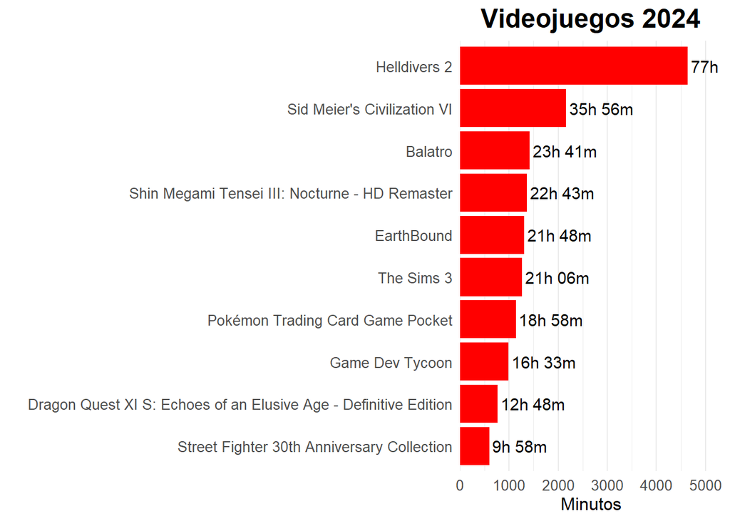

```r
library(tidyverse)
# Calcular top 10
top10 <- journal %>%
  group_by(nombre) %>%
  summarise(minutos = sum(duracion_min, na.rm = TRUE)) %>%
  arrange(desc(minutos)) %>%
  slice_head(n = 10) %>%
  mutate(
    horas = floor(minutos / 60),
    mins = minutos %% 60,
    etiqueta = sprintf("%dh %02dm", horas, mins)
  )

# Gráfica
ggplot(top10, aes(x = reorder(nombre, minutos), y = minutos)) +
  geom_col(fill = "red") +
  geom_text(
    aes(label = etiqueta),
    hjust = -0.05,
    size = 4
  ) +
  coord_flip() +
  scale_y_continuous(expand = expansion(mult = c(0, 0.15))) +
  labs(
    title = "Videojuegos 2024",
    x = "",
    y = "Minutos"
  ) +
  theme_minimal() +
  theme(
    plot.title = element_text(face = "bold", size = 18, hjust = 0.5),
    axis.title = element_text(size = 12),
    axis.text = element_text(size = 10),
    panel.grid.major.y = element_blank()
  )
```

### Tiempo de juego por mes

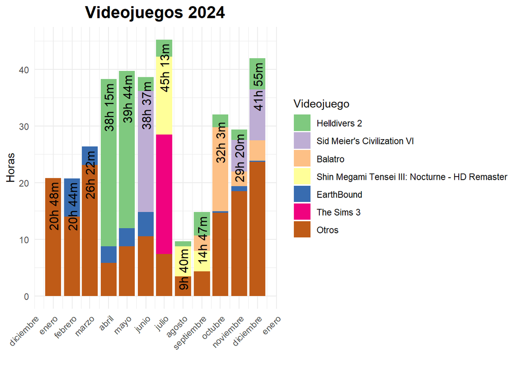

```r
library(tidyverse)
library(lubridate)

# Asegurarse de tener columna de mes
journal <- journal %>%
  mutate(
    fecha = as.Date(fecha),
    mes = floor_date(fecha, "month")
  )

# 1. Calcular los top 6 juegos del año
top6_juegos <- journal %>%
  group_by(nombre) %>%
  summarise(minutos = sum(duracion_min, na.rm = TRUE)) %>%
  slice_max(minutos, n = 6) %>%
  pull(nombre)

# 2. Crear nueva columna para agrupar "Otros"
journal <- journal %>%
  mutate(
    juego_cat = if_else(nombre %in% top6_juegos, nombre, "Otros")
  )

# Convertir en factor con orden deseado
niveles_ordenados <- c(top6_juegos, "Otros")
journal <- journal %>%
  mutate(juego_cat = factor(juego_cat, levels = niveles_ordenados))

# 3. Agrupar por mes y categoría
tiempo_mensual <- journal %>%
  group_by(mes, juego_cat) %>%
  summarise(minutos = sum(duracion_min, na.rm = TRUE), .groups = "drop") %>%
  mutate(horas = minutos / 60)

# 4. Calcular totales por mes para mostrar texto
totales_mes <- tiempo_mensual %>%
  group_by(mes) %>%
  summarise(
    total_minutos = sum(minutos),
    horas = total_minutos %/% 60,
    minutos = total_minutos %% 60,
    etiqueta = paste0(horas, "h ", minutos, "m")
  )

# 5. Crear gráfica
ggplot(tiempo_mensual, aes(x = mes, y = horas, fill = juego_cat)) +
  geom_col() +
  geom_text(data = totales_mes,
            aes(x = mes, y = total_minutos / 60 - 5, label = etiqueta),  # Ajustar posición dentro de la barra
            inherit.aes = FALSE,
            size = 4.2, angle = 90, color = "black") +
  labs(
    title = "Videojuegos 2024",
    x = "",
    y = "Horas",
    fill = "Videojuego"
  ) +
  scale_x_date(
    date_labels = "%B",
    date_breaks = "1 month"
  ) +
  scale_fill_brewer(palette = "Accent") +
  theme_minimal() +
  theme(
    plot.title = element_text(face = "bold", size = 16, hjust = 0.5),
    axis.text.x = element_text(angle = 45, hjust = 1),
    legend.position = "right"
  )
```

### Histograma día de la semana

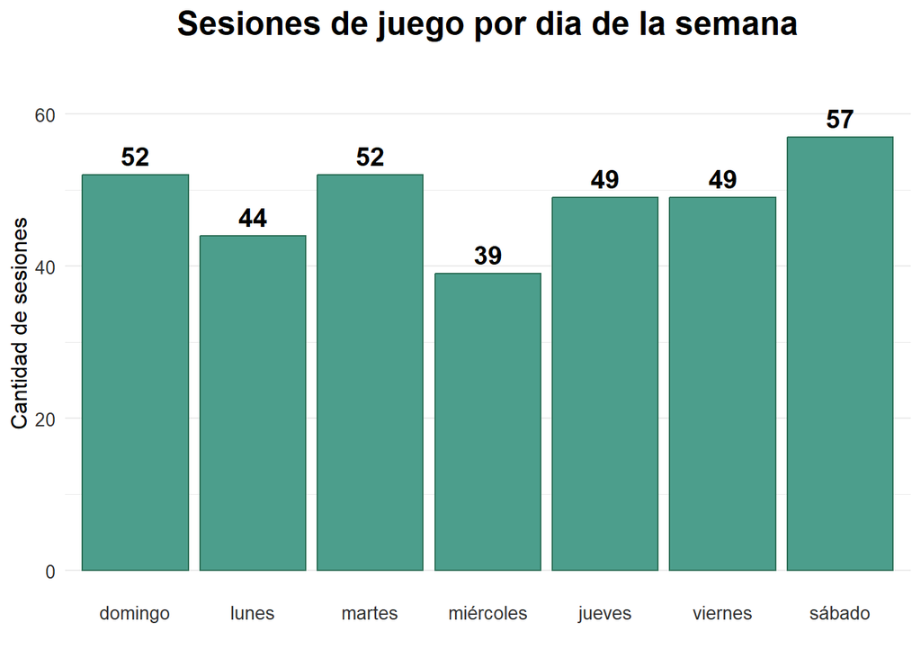

```r
# Crear columna con el día de la semana
journal <- journal %>%
  mutate(dia_semana = wday(fecha, label = TRUE, abbr = FALSE))  # Día de la semana como nombre completo

# Crear histograma del día de la semana
ggplot(journal, aes(x = dia_semana)) +
  geom_bar(fill = "#4C9E8C", color = "#2C6F57", size = 0.5) +  # Colores más suaves
  geom_text(
    stat = "count", aes(label = ..count..), vjust = -0.5, size = 5, fontface = "bold", color = "black"
  ) +  # Agregar la cantidad exacta sobre las barras
  labs(
    title = "Sesiones de juego por dia de la semana",
    x = "",
    y = "Cantidad de sesiones"
  ) +
  scale_y_continuous(limits = c(0, 65)) +  # Limitar el eje Y a un máximo de 60
  theme_minimal() +
  theme(
    plot.title = element_text(face = "bold", size = 18, hjust = 0.5),
    axis.title = element_text(size = 12),
    axis.text = element_text(size = 10, color = "#333333"),
    panel.grid.major.x = element_blank(),
    panel.grid.minor.x = element_blank(),
    axis.ticks.x = element_blank()
  )
```

### Tiempo total por día de la semana

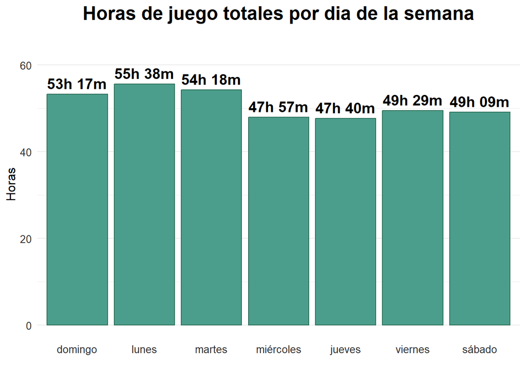

```r
# Crear columna con el día de la semana y convertir la duración en minutos
journal <- journal %>%
  mutate(dia_semana = wday(fecha, label = TRUE, abbr = FALSE),  # Día de la semana como nombre completo
         duracion_min = parse_duration(duracion))  # Asegúrate de convertir la duración a minutos

# Calcular horas y minutos de la duración total
journal <- journal %>%
  mutate(duracion_horas = floor(duracion_min / 60),
         duracion_restante_min = duracion_min %% 60)

# Calcular horas totales de juego por día de la semana
horas_por_dia <- journal %>%
  group_by(dia_semana) %>%
  summarise(horas_totales = sum(duracion_horas), minutos_totales = sum(duracion_restante_min)) %>%
  mutate(
    horas_totales = horas_totales + floor(minutos_totales / 60),
    minutos_totales = minutos_totales %% 60,
    etiqueta = sprintf("%dh %02dm", horas_totales, minutos_totales)
  ) %>%
  arrange(dia_semana)

# Crear gráfico de barras para las horas y minutos de juego
ggplot(horas_por_dia, aes(x = dia_semana, y = horas_totales + minutos_totales / 60)) +
  geom_bar(stat = "identity", fill = "#4C9E8C", color = "#2C6F57", size = 0.5) +  # Colores más suaves
  geom_text(
    aes(label = etiqueta), vjust = -0.5, size = 5, fontface = "bold", color = "black"
  ) +  # Agregar la cantidad exacta de horas y minutos sobre las barras
  labs(
    title = "Horas de juego totales por dia de la semana",
    x = "",
    y = "Horas"
  ) +
  scale_y_continuous(limits = c(0, 65)) +  # Limitar el eje Y a un máximo de 60
  theme_minimal() +
  theme(
    plot.title = element_text(face = "bold", size = 18, hjust = 0.5),
    axis.title = element_text(size = 12),
    axis.text = element_text(size = 10, color = "#333333"),
    panel.grid.major.x = element_blank(),
    panel.grid.minor.x = element_blank(),
    axis.ticks.x = element_blank()
  )
```

### Tiempo total

```r
total_duracion <- sum(journal$duracion_min, na.rm = TRUE)

horas <- total_duracion %/% 60
minutos <- total_duracion %% 60

cat("Tiempo total: ", horas, "horas y", minutos, "minutos\n")
```

```
## Tiempo total:  357 horas y 28 minutos
```

### Trabajo a futuro

- Webscraping más eficiente que recopile más información.
- Añadir datos de género, desarrollador, plataforma, año de lanzamiento, país, etcétera.
- Crear un dashboard para conocer a detalle cada juego o mes.